# En el recuento de los daños

Fuente: Journalists Killed since 1992 https://cpj.org/

Por: Centro de Análisis de Datos [CAD](https://github.com/Songeo/analisis_periodistas.git)

A raíz de los conflictos sociales alrededor del mundo se ha observado un incremento en la amenaza a la libertad de expresión y libertad de prensa.

Intentaremos contestar preguntas sobre lo que pasa en el mundo y en México.

### ¿Cuántos han muerto en el mundo?

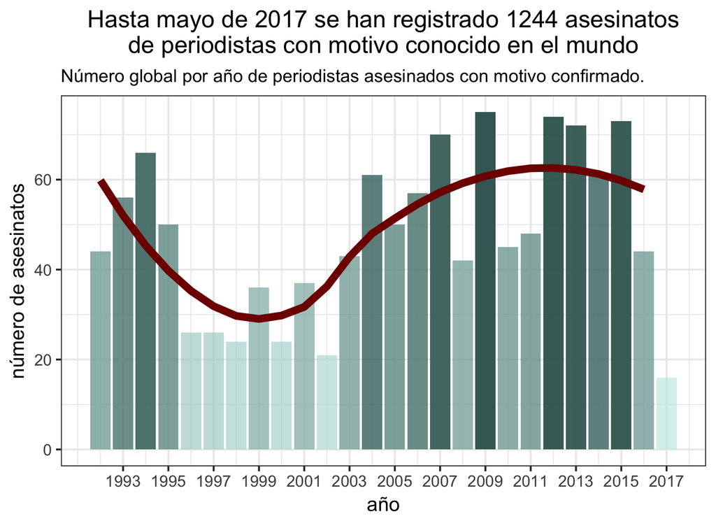

### ¿Y en México?

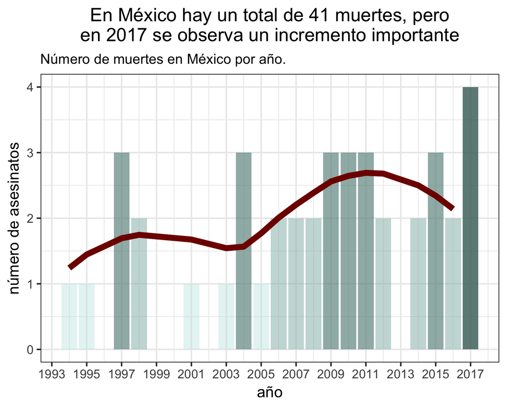

### ¿Cuál es la causa de muerte?

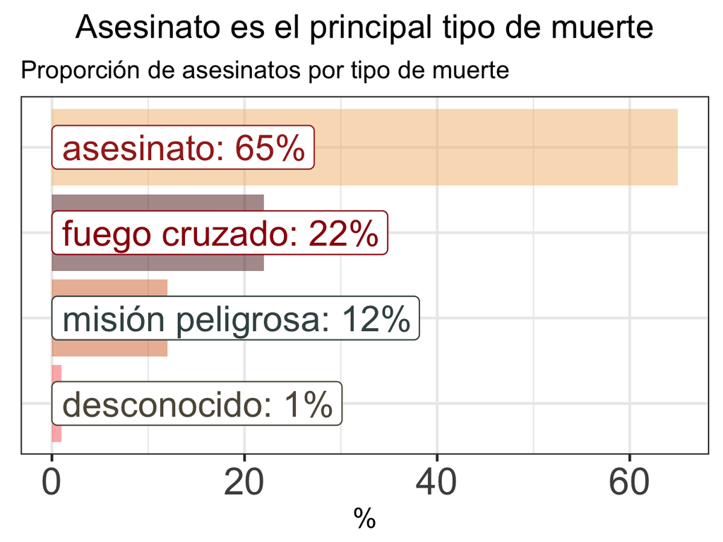

### ¿Dónde está México?

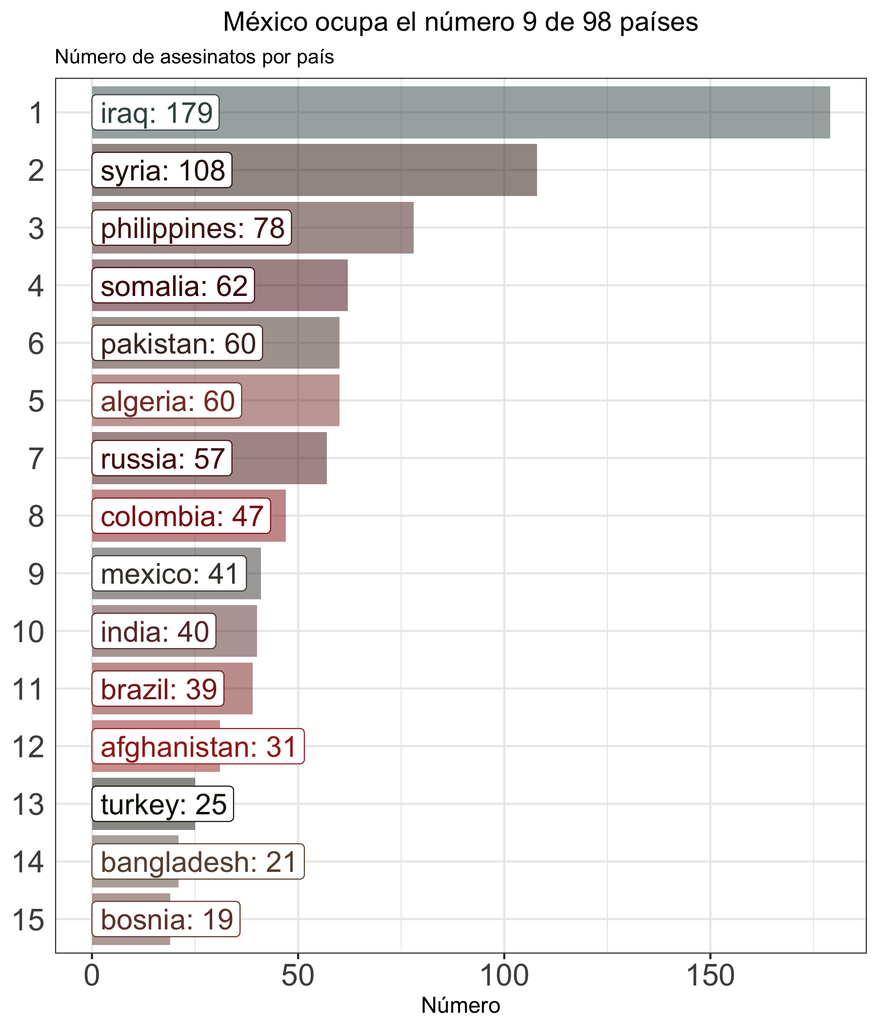

#### ¿Tipo de Muerte?

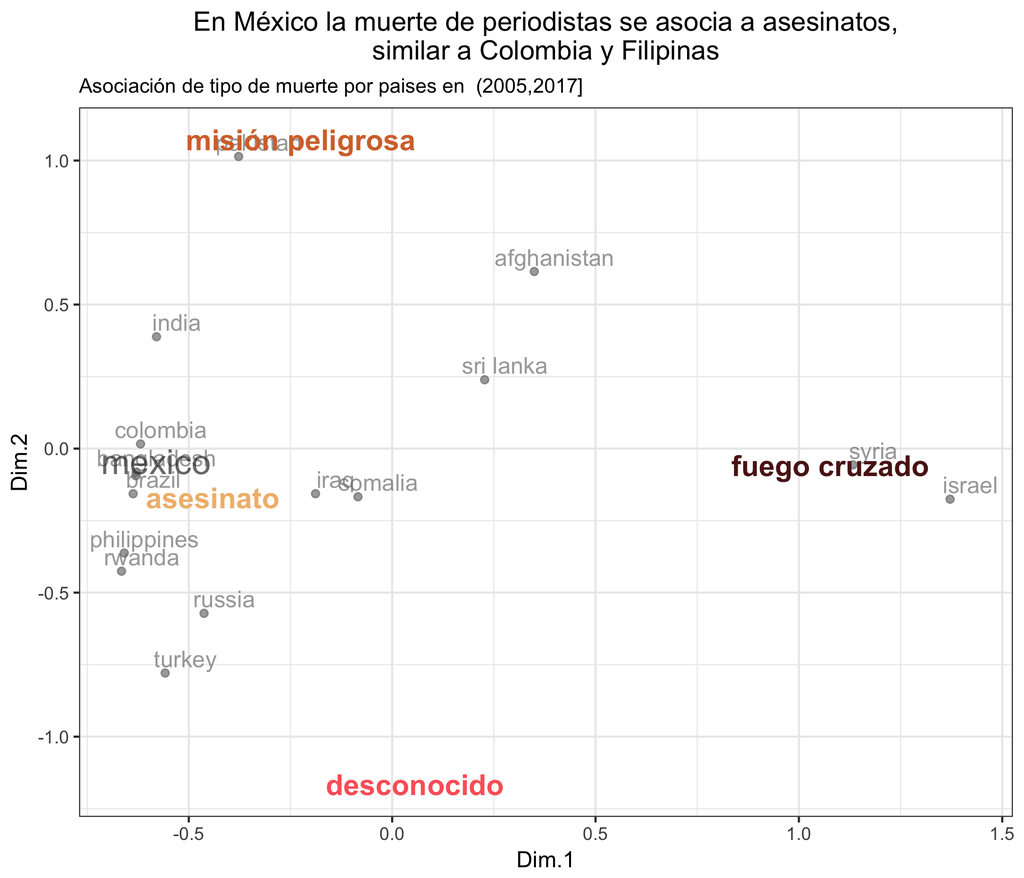

#### ¿Fuente de Fuego?

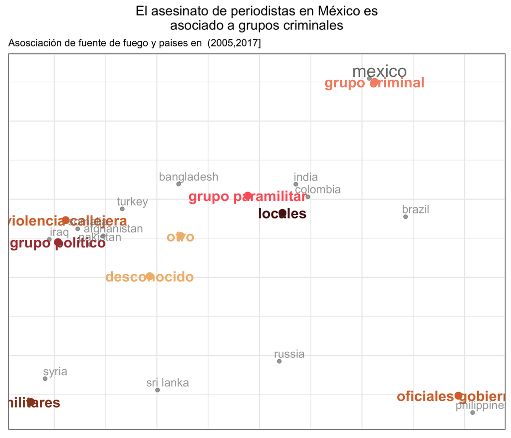

#### ¿Impunidad?

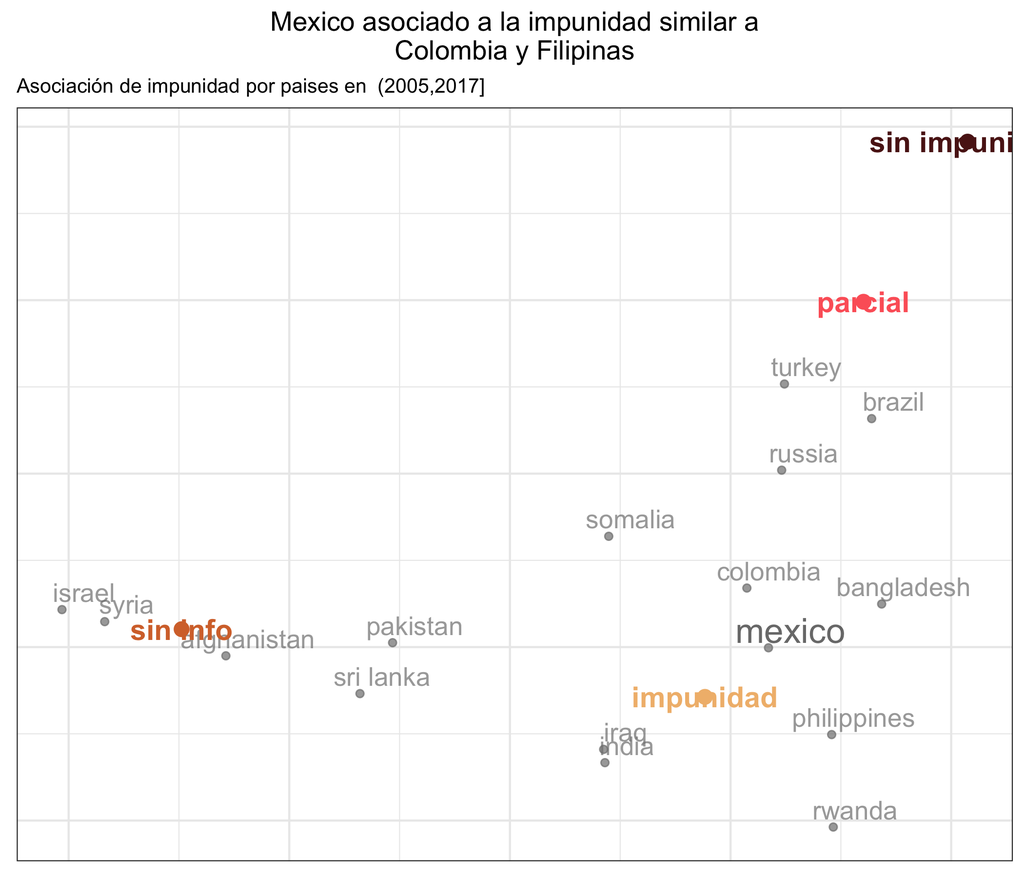

### ¿Quiénes están matando periodistas en México?

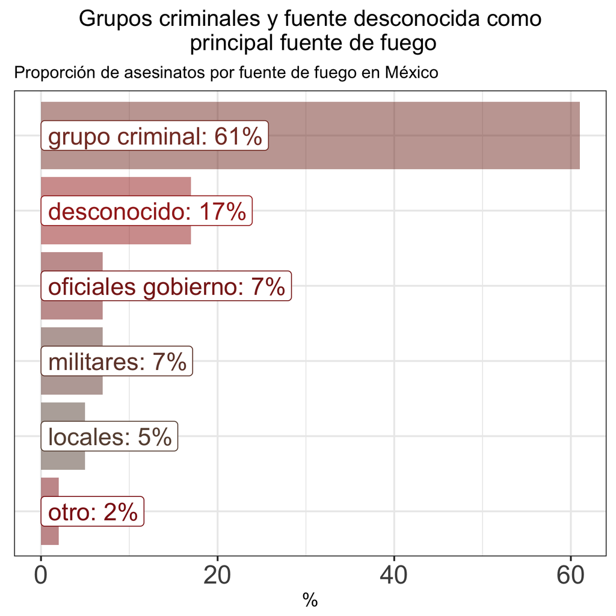

### ¿Quienes salen impunes en México?

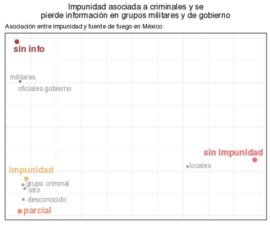

### Conclusión

La democracia es un ideal universalmente reconocido y es uno de los valores fundamentales de las Naciones Unidas, organización de la que México es miembro. México al reconocerse como un país democrático tienen la responsabilidad y el compromiso de asegurar la libertad de expresión, enfatizando que éste es un pilar de la democracia que asegura el intercambio de ideas y opiniones en una sociedad plural.

Sin embargo, podemos observar que México ha fallado, tanto en garantizar la seguridad de los periodistas al ocupar el noveno lugar con mayor asesinatos a nivel mundial, así como en procurar la justicia sobre los asesinatos al observarse una asociación del país a la impunidad total.

Es cierto que el país se encuentra en una situación compleja ante un problema complejo, pero como comentó Angela Merkel en su visita a México, es vital que la libertad de expresión sea respetada, ya que citando a Christiane Amanpour: *una batalla de información está en marcha en todo el mundo, y está evolucionando de manera extremadamente peligrosa*.

Fuente:

http://www.noroeste.com.mx/publicaciones/view/se_necesita_libertad_de_prensa_en_mexico_angela_merkel-1086600

http://www.un.org/en/sections/issues-depth/democracy/

https://cpj.org/2015/04/attacks-on-the-press-foreword.php

El conjunto de datos presentado por el Comité para la Protección de Periodistas (Committee to Protect Journalist CPJ) es recolección de asesinatos de periodistas desde 1992 hasta mayo de 2017 en aproximadamente 105 países.

Únicamente se consideraron los asesinatos de periodistas con motivo confirmado. Se descartó el asesinato de miembros del staff o ayudantes como traductores.